# Statistics Dashboard: HIV Deaths and Medical Doctors

Author

Charles O

# Introduction

This dashboard explores the relationship between **annual HIV deaths** and the availability of **medical doctors per 1000 people**. The goal is to highlight trends, disparities, and possible correlations between these indicators.

The dashboard is divided into three main sections:

1. Annual HIV Deaths.
2. Medical Doctors per 1000 People.
3. Relationship Between the Two Indicators.

```python
# Load libraries
import pandas as pd
import country_converter as coco
import plotly.express as px
import seaborn as sns
import geopandas as gpd
import matplotlib.pyplot as plt
```

Data were accessed from the Gapminder foundation, at www.gapminder.org/data.

1. **Annual HIV Deaths Dataset:** This dataset provides the annual number of deaths attributable to HIV/AIDS
2. **Medical Doctors per 1,000 People:** This dataset measures the number of medical doctors per 1,000 people, representing healthcare resource availability at national or subnational levels

```python
# Load raw data
hiv_deaths_raw = pd.read_csv("data/annual_hiv_deaths_number_all_ages.csv")
medical_doctors_raw = pd.read_csv("data/medical_doctors_per_1000_people.csv")
```

```python
# converting to log format

hiv_deaths_raw_wide = hiv_deaths_raw

hiv_deaths_long = hiv_deaths_raw_wide.melt(
    id_vars=["country"], var_name="year", value_name="hiv_deaths"
)
```

```python
medical_doctors_raw_wide = medical_doctors_raw
medical_doctors_long = medical_doctors_raw_wide.melt(
    id_vars=["country"],
    var_name="year",
    value_name = "doctors_per_1000"
)
medical_doctors_long['number_of_doctors'] = medical_doctors_long['doctors_per_1000'] * 1000
```

```python
# Convert non-numeric values in 'hiv_deaths' to numeric (e.g., '11k' to 11000)
hiv_deaths_long['hiv_deaths'] = (
    hiv_deaths_long['hiv_deaths']
    .replace(r'[^\d.]k', lambda x: float(x.group(0).strip('k')) * 1000, regex=True)
    .replace(r'[^\d.]', '', regex=True)
    .astype(float, errors='ignore')
)
```

```python
#Convert year to integer and clean numeric columns
hiv_deaths_long['year'] = pd.to_numeric(hiv_deaths_long['year'], errors='coerce')
medical_doctors_long['year'] = pd.to_numeric(medical_doctors_long['year'], errors='coerce')
```

```python
# Step 3: Align datasets by filtering overlapping years
common_years = set(hiv_deaths_long['year']).intersection(medical_doctors_long['year'])
hiv_deaths_long = hiv_deaths_long[hiv_deaths_long['year'].isin(common_years)]
medical_doctors_long = medical_doctors_long[medical_doctors_long['year'].isin(common_years)]
```

```python
# Step 4: Merge datasets on 'country' and 'year'
merged_data = pd.merge(hiv_deaths_long, medical_doctors_long, on=["country", "year"], how="inner")
```

```python
# Step 5: Drop duplicates and save the cleaned dataset
merged_data = merged_data.drop_duplicates()
```

```python
# Save to a CSV file
merged_data.to_csv("data/cleaned_merged_dataset.csv", index=False)

# Display a preview of the cleaned and merged dataset
```

# Annual HIV Deaths

```python
# Value box for country with highest HIV deaths in the most recent year
most_recent_year = merged_data["year"].max()
highest_deaths = merged_data[merged_data["year"] == most_recent_year].sort_values("hiv_deaths", ascending=False).iloc[0]
highest_deaths_country = highest_deaths["country"]
highest_deaths_value = highest_deaths["hiv_deaths"]
```

9700

DEATHS in 2011

```python
# Table summarizing statistics for the most recent year
summary_stats = merged_data[merged_data["year"] == most_recent_year][["country", "hiv_deaths"]].sort_values("hiv_deaths", ascending=False)
summary_stats.head(10)
```

|  | country | hiv_deaths |
| --- | --- | --- |
| 3157 | Colombia | 9700.0 |
| 3193 | Iran | 8300.0 |
| 3258 | Eswatini | 6800.0 |
| 3244 | Rwanda | 6400.0 |
| 3188 | Haiti | 5800.0 |
| 3245 | Sudan | 5600.0 |
| 3226 | Namibia | 5200.0 |
| 3216 | Mexico | 4900.0 |
| 3227 | Niger | 4000.0 |
| 3250 | Somalia | 3100.0 |

## Trends in Annual HIV Deaths

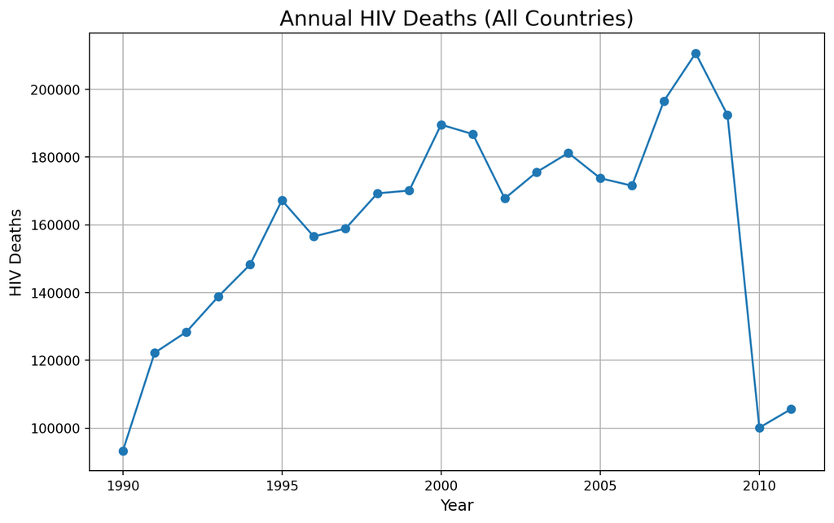

```python
# Aggregate data for the line chart
annual_hiv_deaths = merged_data.groupby("year")["hiv_deaths"].sum()
# Create line chart
plt.figure(figsize=(10, 6))
plt.plot(annual_hiv_deaths.index, annual_hiv_deaths.values, marker="o", linestyle="-")
plt.title("Annual HIV Deaths (All Countries)", fontsize=16)
plt.xlabel("Year", fontsize=12)
plt.ylabel("HIV Deaths", fontsize=12)
plt.grid(True)
plt.show()
```

# Medical Doctors per 1000 People

## Top 10 Countries by Doctors per 1000 People

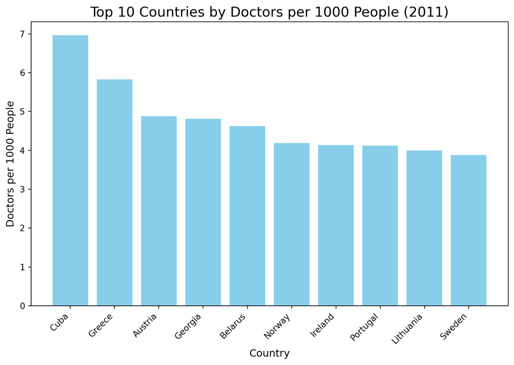

```python
# Aggregate data for a specific year (2011))
yearly_data = merged_data[merged_data['year'] == 2011].dropna(subset=['doctors_per_1000'])

# Sort by doctors_per_1000 for better visualization
yearly_data = yearly_data.sort_values(by='doctors_per_1000', ascending=False).head(10)

# Create bar chart
plt.figure(figsize=(10, 6))
plt.bar(yearly_data['country'], yearly_data['doctors_per_1000'], color='skyblue')
plt.title('Top 10 Countries by Doctors per 1000 People (2011)', fontsize=16)
plt.xlabel('Country', fontsize=12)
plt.ylabel('Doctors per 1000 People', fontsize=12)
plt.xticks(rotation=45, ha='right')
plt.show()
```

Cuba leads with the highest number of doctors per 1000 people, followed by Greece and Austria. This demonstrates significant disparities in healthcare resources between countries, likely impacting healthcare outcomes

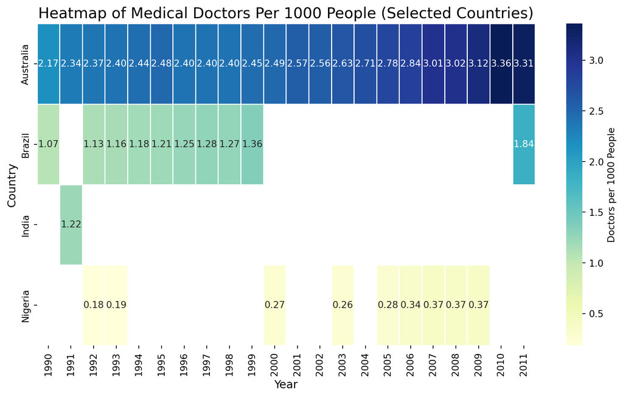

```python
# Select 5 countries from 5 continents
selected_countries = [
    "United States",
    "Nigeria",
    "Brazil",
    "Australia",
    "India",
]  # Customize based on your dataset

# Filter the dataset
filtered_data = merged_data[merged_data["country"].isin(selected_countries)]

# Prepare data for heatmap
heatmap_data = filtered_data.pivot_table(
    index="country", columns="year", values="doctors_per_1000"
)

# Plot the heatmap
plt.figure(figsize=(10, 6))
sns.heatmap(
    heatmap_data,
    cmap="YlGnBu",
    cbar_kws={"label": "Doctors per 1000 People"},
    linewidths=0.5,
    annot=True,
    fmt=".2f",  # Annotate cells with data values
)
plt.title(
    "Heatmap of Medical Doctors Per 1000 People (Selected Countries)", fontsize=16
)
plt.xlabel("Year", fontsize=12)
plt.ylabel("Country", fontsize=12)
plt.tight_layout()
plt.show()
```

Australia consistently shows high levels of doctors per 1000 people over the years, while Nigeria exhibits significantly lower levels. This disparity highlights the challenges of healthcare accessibility in resource-constrained settings like Nigeria.

# Relationship Between HIV Deaths and Medical Doctors

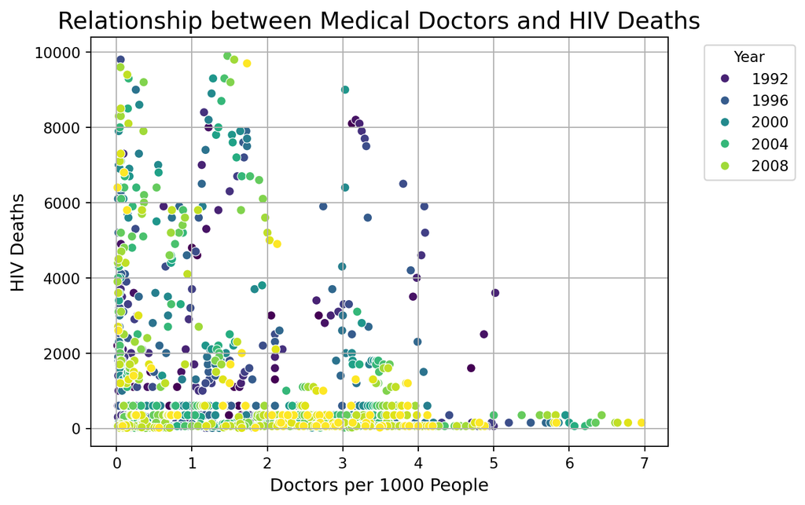

```python
import seaborn as sns
import matplotlib.pyplot as plt

# Create the scatter plot and assign it to scatter_one
scatter_one = sns.scatterplot(
    data=merged_data,
    x="doctors_per_1000",
    y="hiv_deaths",
    hue="year",
    palette="viridis",
)

# Set plot title and labels
scatter_one.set_title(
    "Relationship between Medical Doctors and HIV Deaths", fontsize=16
)
scatter_one.set_xlabel("Doctors per 1000 People", fontsize=12)
scatter_one.set_ylabel("HIV Deaths", fontsize=12)

# Adjust legend position
scatter_one.legend(title="Year", bbox_to_anchor=(1.05, 1), loc="upper left")

# Enable grid for better readability
scatter_one.grid(True)
```

There is a general inverse relationship between the number of doctors and HIV deaths, with higher doctor density correlating with lower mortality. However, some countries deviate from this trend, suggesting the influence of other factors like epidemic severity.

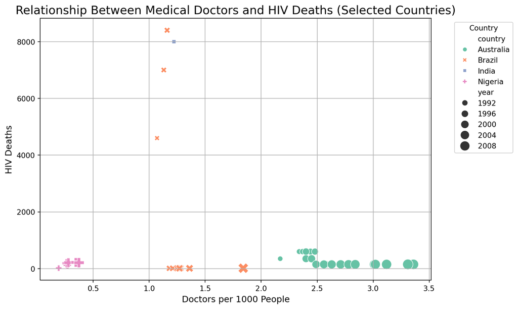

```python
# Select the same 5 countries
selected_countries = ['United States', 'Nigeria', 'Brazil', 'Australia', 'India']

# Filter the dataset for these countries
filtered_scatter_data = merged_data[merged_data['country'].isin(selected_countries)]

# Create scatter plot
plt.figure(figsize=(10, 6))
sns.scatterplot(
    data=filtered_scatter_data,
    x='doctors_per_1000',
    y='hiv_deaths',
    hue='country',
    style='country',
    size='year',
    sizes=(50, 200),
    palette='Set2'
)
plt.title('Relationship Between Medical Doctors and HIV Deaths (Selected Countries)', fontsize=16)
plt.xlabel('Doctors per 1000 People', fontsize=12)
plt.ylabel('HIV Deaths', fontsize=12)
plt.legend(title='Country', bbox_to_anchor=(1.05, 1), loc='upper left')
plt.grid(True)
plt.tight_layout()
plt.show()
```

Among selected countries, Brazil shows higher HIV deaths despite moderate doctor density, while Australia consistently maintains low deaths with high doctor availability. This reflects the impact of healthcare infrastructure and epidemic management strategies.